# Problem 1

## The Student News Service at Clear Mountain State University (CMSU) has decided to gather data about the undergraduate students that attend CMSU. CMSU creates and distributes a survey of 14 questions and receives responses from 62 undergraduates

```python
import pandas as pd
import numpy as np
import matplotlib
import matplotlib.pyplot as plt
import seaborn as sns
import scipy.stats as stats
import statsmodels.stats.api as sm
import copy
```

```python
import os
```

```python
os.getcwd()
```

```
'/Users/sharageorgevaidian'
```

```python
os.chdir('/Users/sharageorgevaidian/Downloads')
```

```python
data = pd.read_csv('Survey-1.csv')
```

```python
data
```

|  | ID | Gender | Age | Class | Major | Grad Intention | GPA | Employment | Salary | Social Networking | Satisfaction | Spending | Computer | Text Messages |
| --- | --- | --- | --- | --- | --- | --- | --- | --- | --- | --- | --- | --- | --- | --- |
| 0 | 1 | Female | 20 | Junior | Other | Yes | 2.9 | Full-Time | 50.0 | 1 | 3 | 350 | Laptop | 200 |
| 1 | 2 | Male | 23 | Senior | Management | Yes | 3.6 | Part-Time | 25.0 | 1 | 4 | 360 | Laptop | 50 |
| 2 | 3 | Male | 21 | Junior | Other | Yes | 2.5 | Part-Time | 45.0 | 2 | 4 | 600 | Laptop | 200 |
| 3 | 4 | Male | 21 | Junior | CIS | Yes | 2.5 | Full-Time | 40.0 | 4 | 6 | 600 | Laptop | 250 |
| 4 | 5 | Male | 23 | Senior | Other | Undecided | 2.8 | Unemployed | 40.0 | 2 | 4 | 500 | Laptop | 100 |
| ... | ... | ... | ... | ... | ... | ... | ... | ... | ... | ... | ... | ... | ... | ... |
| 57 | 58 | Female | 21 | Senior | International Business | No | 2.4 | Part-Time | 40.0 | 1 | 3 | 1000 | Laptop | 10 |
| 58 | 59 | Female | 20 | Junior | CIS | No | 2.9 | Part-Time | 40.0 | 2 | 4 | 350 | Laptop | 250 |
| 59 | 60 | Female | 20 | Sophomore | CIS | No | 2.5 | Part-Time | 55.0 | 1 | 4 | 500 | Laptop | 500 |
| 60 | 61 | Female | 23 | Senior | Accounting | Yes | 3.5 | Part-Time | 30.0 | 2 | 3 | 490 | Laptop | 50 |
| 61 | 62 | Female | 23 | Senior | Economics/Finance | No | 3.2 | Part-Time | 70.0 | 2 | 3 | 250 | Laptop | 0 |

62 rows × 14 columns

```python
data.info()
```

```
<class 'pandas.core.frame.DataFrame'>
RangeIndex: 62 entries, 0 to 61
Data columns (total 14 columns):
 #   Column             Non-Null Count  Dtype
---  ------             --------------  -----
 0   ID                 62 non-null     int64
 1   Gender             62 non-null     object
 2   Age                62 non-null     int64
 3   Class              62 non-null     object
 4   Major              62 non-null     object
 5   Grad Intention     62 non-null     object
 6   GPA                62 non-null     float64
 7   Employment         62 non-null     object
 8   Salary             62 non-null     float64
 9   Social Networking  62 non-null     int64
 10  Satisfaction       62 non-null     int64
 11  Spending           62 non-null     int64
 12  Computer           62 non-null     object
 13  Text Messages      62 non-null     int64
dtypes: float64(2), int64(6), object(6)
memory usage: 6.9+ KB
```

```python
data.isnull()
```

|  | ID | Gender | Age | Class | Major | Grad Intention | GPA | Employment | Salary | Social Networking | Satisfaction | Spending | Computer | Text Messages |
| --- | --- | --- | --- | --- | --- | --- | --- | --- | --- | --- | --- | --- | --- | --- |
| 0 | False | False | False | False | False | False | False | False | False | False | False | False | False | False |
| 1 | False | False | False | False | False | False | False | False | False | False | False | False | False | False |
| 2 | False | False | False | False | False | False | False | False | False | False | False | False | False | False |
| 3 | False | False | False | False | False | False | False | False | False | False | False | False | False | False |
| 4 | False | False | False | False | False | False | False | False | False | False | False | False | False | False |
| ... | ... | ... | ... | ... | ... | ... | ... | ... | ... | ... | ... | ... | ... | ... |
| 57 | False | False | False | False | False | False | False | False | False | False | False | False | False | False |
| 58 | False | False | False | False | False | False | False | False | False | False | False | False | False | False |
| 59 | False | False | False | False | False | False | False | False | False | False | False | False | False | False |
| 60 | False | False | False | False | False | False | False | False | False | False | False | False | False | False |
| 61 | False | False | False | False | False | False | False | False | False | False | False | False | False | False |

62 rows × 14 columns

```python
data.isnull().sum()
```

```
ID                   0
Gender               0
Age                  0
Class                0
Major                0
Grad Intention       0
GPA                  0
Employment           0
Salary               0
Social Networking    0
Satisfaction         0
Spending             0
Computer             0
Text Messages        0
dtype: int64
```

## 1. For this data, construct the following contingency tables (Keep Gender as row variable)

1.1.1. Gender and Major

```python
pd.crosstab(index=data['Gender'], columns=data['Major'])
```

| Major Gender | Accounting | CIS | Economics/Finance | International Business | Management | Other | Retailing/Marketing | Undecided |
| --- | --- | --- | --- | --- | --- | --- | --- | --- |
| Female | 3 | 3 | 7 | 4 | 4 | 3 | 9 | 0 |
| Male | 4 | 1 | 4 | 2 | 6 | 4 | 5 | 3 |

1.1.2. Gender and Grad Intention

```python
pd.crosstab(index=data['Gender'], columns=data['Grad Intention'])
```

| Grad Intention Gender | No | Undecided | Yes |
| --- | --- | --- | --- |
| Female | 9 | 13 | 11 |
| Male | 3 | 9 | 17 |

1.1.3. Gender and Employment

```python
pd.crosstab(index=data['Gender'], columns=data['Employment'])
```

| Employment Gender | Full-Time | Part-Time | Unemployed |
| --- | --- | --- | --- |
| Female | 3 | 24 | 6 |
| Male | 7 | 19 | 3 |

1.1.4. Gender and Computer

```python
pd.crosstab(index=data['Gender'], columns=data['Computer'])
```

| Computer Gender | Desktop | Laptop | Tablet |
| --- | --- | --- | --- |
| Female | 2 | 29 | 2 |
| Male | 3 | 26 | 0 |

## 1.2. Assume that the sample is representative of the population of CMSU. Based on the data, answer the following question:

1.2.1. What is the probability that a randomly selected CMSU student will be male?

```python
print(data['Gender'].value_counts()['Male'])
print(data['Gender'].value_counts()['Female'])
```

```
29
33
```

The total number of students = 62.

Then P(Male) = 29/62 = 0.46774194 = 46.77%

1.2.2. What is the probability that a randomly selected CMSU student will be female?

The total number of students = 62. Then P(Female) = 33/62 = 0.53225806 = 53.22%

## 1.3. Assume that the sample is representative of the population of CMSU. Based on the data, answer the following question:

1.3.1. Find the conditional probability of different majors among the male students in CMSU.

```python
pd.crosstab(index=data['Gender'], columns=data['Major'])
```

| Major Gender | Accounting | CIS | Economics/Finance | International Business | Management | Other | Retailing/Marketing | Undecided |
| --- | --- | --- | --- | --- | --- | --- | --- | --- |
| Female | 3 | 3 | 7 | 4 | 4 | 3 | 9 | 0 |
| Male | 4 | 1 | 4 | 2 | 6 | 4 | 5 | 3 |

Probability of Males opting for accounting. is 4/29 = 13.793103448275861 %

Probability of Males opting for CIS. is 1/29 = 3.4482758620689653 %

Probability of Males opting for Economics/Finance. is 4/29 = 13.793103448275861 %

Probability of Males opting for International Business. is 2/29 = 6.896551724137931 %

Probability of Males opting for Management. is 6/29 = 20.689655172413794 %

Probability of Males opting for Other. is 4/29 = 13.793103448275861 %

Probability of Males opting for Retailing/Marketing. is 5/29 = 17.24137931034483 %

Probability of Males opting for Undecided. is 3/29 = 10.344827586206897 %

1.3.2 Find the conditional probability of different majors among the female students of CMSU.

```python
pd.crosstab(index=data['Gender'], columns=data['Major'])
```

| Major Gender | Accounting | CIS | Economics/Finance | International Business | Management | Other | Retailing/Marketing | Undecided |
| --- | --- | --- | --- | --- | --- | --- | --- | --- |
| Female | 3 | 3 | 7 | 4 | 4 | 3 | 9 | 0 |
| Male | 4 | 1 | 4 | 2 | 6 | 4 | 5 | 3 |

Probability of Females opting for accounting. is 3/33 = 9.090909090909092 %

Probability of Females opting for CIS. is 3/33 = 9.090909090909092 %

Probability of Females opting for Economics/Finance. is 7/33 = 21.21212121212121 %

Probability of Females opting for International Business. is 4/33 = 12.121212121212121 %

Probability of Females opting for Management. is 4/33 = 12.121212121212121 %

Probability of Females opting for Other. is 3/33 = 9.090909090909092 %

Probability of Females opting for Retailing/Marketing. is 9/33 = 27.27272727272727 %

Probability of Females opting for Undecided. is 0/33 = 0.0 %

## 1.4. Assume that the sample is a representative of the population of CMSU. Based on the data, answer the following question:

```python
pd.crosstab(index=data['Gender'], columns=data['Grad Intention'])
```

| Grad Intention Gender | No | Undecided | Yes |
| --- | --- | --- | --- |
| Female | 9 | 13 | 11 |
| Male | 3 | 9 | 17 |

```python
pd.crosstab(index=data['Gender'], columns=data['Computer'])
```

| Computer Gender | Desktop | Laptop | Tablet |
| --- | --- | --- | --- |
| Female | 2 | 29 | 2 |
| Male | 3 | 26 | 0 |

## 1.5. Assume that the sample is representative of the population of CMSU. Based on the data, answer the following question:

1.5.1. Find the probability that a randomly chosen student is a male or has full-time employment?

```python
pd.crosstab(index=data['Gender'], columns=data['Employment'])
```

| Employment Gender | Full-Time | Part-Time | Unemployed |
| --- | --- | --- | --- |
| Female | 3 | 24 | 6 |
| Male | 7 | 19 | 3 |

Total no. of employed people: 62

Total no. of Males: 29

Total mo: of male full time employees = 7

P(andomly chosen student is a male or has full-time employment) = (((29+10)-7)/62)) * 100 = 51.6129032258%

1.5.2. Find the conditional probability that given a female student is randomly chosen, she is majoring in international business or management.

```python
pd.crosstab(index=data['Gender'], columns=data['Major'])
```

| Major Gender | Accounting | CIS | Economics/Finance | International Business | Management | Other | Retailing/Marketing | Undecided |
| --- | --- | --- | --- | --- | --- | --- | --- | --- |
| Female | 3 | 3 | 7 | 4 | 4 | 3 | 9 | 0 |
| Male | 4 | 1 | 4 | 2 | 6 | 4 | 5 | 3 |

P( a female student is randomly chosen, she is majoring in international business or management.) = ((4+4)/33)*100 = 24.24242424242%

## 1.6. Construct a contingency table of Gender and Intent to Graduate at 2 levels (Yes/No). The Undecided students are not considered now and the table is a 2x2 table. Do you think the graduate intention and being female are independent events?

```python
ct=pd.crosstab(data['Gender'],data['Grad Intention'] )
block = pd.DataFrame(ct)
block[['Yes','No']]
```

| Grad Intention Gender | Yes | No |
| --- | --- | --- |
| Female | 11 | 9 |
| Male | 17 | 3 |

Total number of students = 40

Number of females = 20

Number of student Graduation Intent Yes = 28

Number of female Graduation Intent Yes = 11

Probability female = 20/40

Probability student Graduation Intent Yes = 28/40 P(A)*P(B) = 28/80 Probability female = 20/40 Probability Graduation Intent Yes | Female = 11/20 P(A|B)* P(B) = 11/40 P(A)*P(B) = 0.35 P(A|B)* P(B) = 0.275 The events are dependent.

## 1.7. Note that there are four numerical (continuous) variables in the data set, GPA, Salary, Spending, and Text Messages.

Answer the following questions based on the data

1.7.1. If a student is chosen randomly, what is the probability that his/her GPA is less than 3?

```python
pd.crosstab(data['Gender'],data['GPA'])
```

| GPA Gender | 2.3 | 2.4 | 2.5 | 2.6 | 2.8 | 2.9 | 3.0 | 3.1 | 3.2 | 3.3 | 3.4 | 3.5 | 3.6 | 3.7 | 3.8 | 3.9 |
| --- | --- | --- | --- | --- | --- | --- | --- | --- | --- | --- | --- | --- | --- | --- | --- | --- |
| Female | 1 | 1 | 2 | 0 | 1 | 3 | 5 | 2 | 4 | 3 | 2 | 4 | 1 | 2 | 1 | 1 |
| Male | 0 | 0 | 4 | 2 | 2 | 1 | 2 | 5 | 2 | 2 | 5 | 2 | 2 | 0 | 0 | 0 |

```python
print('Probability that a student is chosen at random given his/her GPA is less than 3 =',17/62)
```

```
Probability that a student is chosen at random given his/her GPA is less than 3 = 0.27419354838709675
```

1.7.2. Find the conditional probability that a randomly selected male earns 50 or more. Find the conditional probability that a randomly selected female earns 50 or more.

```python
pd.crosstab(data['Gender'],data['Salary'])
```

| Salary Gender | 25.0 | 30.0 | 35.0 | 37.0 | 37.5 | 40.0 | 42.0 | 45.0 | 47.0 | 47.5 | 50.0 | 52.0 | 54.0 | 55.0 | 60.0 | 65.0 | 70.0 | 78.0 | 80.0 |
| --- | --- | --- | --- | --- | --- | --- | --- | --- | --- | --- | --- | --- | --- | --- | --- | --- | --- | --- | --- |
| Female | 0 | 5 | 1 | 0 | 1 | 5 | 1 | 1 | 0 | 1 | 5 | 0 | 0 | 5 | 5 | 0 | 1 | 1 | 1 |
| Male | 1 | 0 | 1 | 1 | 0 | 7 | 0 | 4 | 1 | 0 | 4 | 1 | 1 | 3 | 3 | 1 | 0 | 0 | 1 |

```python
print('From the contigency table we can find that the total number of male candidates who earn 50 or more is 14')
print('From the contigency table we can find that the total number of female candidates who earn 50 or more is 18')
print('The probability that a randomly selected male earns 50 or more is',14/29)
print('The probability that a randomly selected female earns 50 or more is',18/33)
```

```
From the contigency table we can find that the total number of male candidates who earn 50 or more is 14
From the contigency table we can find that the total number of female candidates who earn 50 or more is 18
The probability that a randomly selected male earns 50 or more is 0.4827586206896552
The probability that a randomly selected female earns 50 or more is 0.5454545454545454
```

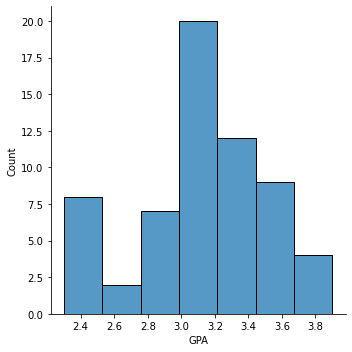

```python
sns.displot(data['GPA'])
plt.show()
```

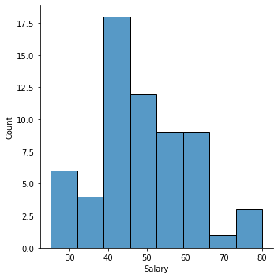

```python
sns.displot(data['Salary'])
plt.show()
```

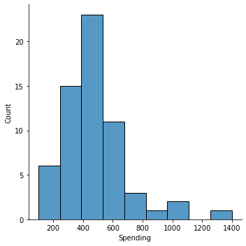

```python
sns.displot(data['Spending'])
plt.show()
```

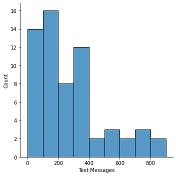

```python
sns.displot(data['Text Messages'])
plt.show()
```

# Problem 2 (Download DataView in a new window)

An important quality characteristic used by the manufacturers of ABC asphalt shingles is the amount of moisture the shingles contain when they are packaged. Customers may feel that they have purchased a product lacking in quality if they find moisture and wet shingles inside the packaging. In some cases, excessive moisture can cause the granules attached to the shingles for texture and coloring purposes to fall off the shingles resulting in appearance problems. To monitor the amount of moisture present, the company conducts moisture tests. A shingle is weighed and then dried. The shingle is then reweighed, and based on the amount of moisture taken out of the product, the pounds of moisture per 100 square feet is calculated. The company would like to show that the mean moisture content is less than 0.35 pounds per 100 square feet.

## 2.1 Do you think there is evidence that means moisture contents in both types of shingles are within the permissible limits? State your conclusions clearly showing all steps.

```python
abc= pd.read_csv("A+&+B+shingles.csv")
```

```python
abc
```

|  | A | B |
| --- | --- | --- |
| 0 | 0.44 | 0.14 |
| 1 | 0.61 | 0.15 |
| 2 | 0.47 | 0.31 |
| 3 | 0.30 | 0.16 |
| 4 | 0.15 | 0.37 |
| 5 | 0.24 | 0.18 |
| 6 | 0.16 | 0.42 |
| 7 | 0.20 | 0.58 |
| 8 | 0.20 | 0.25 |
| 9 | 0.20 | 0.41 |
| 10 | 0.26 | 0.17 |
| 11 | 0.14 | 0.13 |
| 12 | 0.33 | 0.23 |
| 13 | 0.13 | 0.11 |
| 14 | 0.72 | 0.10 |
| 15 | 0.51 | 0.19 |
| 16 | 0.28 | 0.22 |
| 17 | 0.39 | 0.44 |
| 18 | 0.39 | 0.11 |
| 19 | 0.25 | 0.11 |
| 20 | 0.16 | 0.31 |
| 21 | 0.20 | 0.43 |
| 22 | 0.22 | 0.26 |
| 23 | 0.42 | 0.18 |
| 24 | 0.24 | 0.44 |
| 25 | 0.21 | 0.43 |
| 26 | 0.49 | 0.16 |
| 27 | 0.34 | 0.52 |
| 28 | 0.36 | 0.36 |
| 29 | 0.29 | 0.22 |
| 30 | 0.27 | 0.39 |
| 31 | 0.40 | NaN |
| 32 | 0.29 | NaN |
| 33 | 0.43 | NaN |
| 34 | 0.34 | NaN |
| 35 | 0.37 | NaN |

```python
abc.describe(include='all').T
```

|  | count | mean | std | min | 25% | 50% | 75% | max |
| --- | --- | --- | --- | --- | --- | --- | --- | --- |
| A | 36.0 | 0.316667 | 0.135731 | 0.13 | 0.2075 | 0.29 | 0.3925 | 0.72 |
| B | 31.0 | 0.273548 | 0.137296 | 0.10 | 0.1600 | 0.23 | 0.4000 | 0.58 |

## 2.1 Do you think there is evidence that means moisture contents in both types of shingles are within the permissible limits? State your conclusions clearly showing all steps.

FOR A

H0 : mean moisture content <=0.35

HA : mean moisture content > 0.35

Level of Significance = 0.05

```python
A= abc.copy()
del A['B']
A
```

|  | A |
| --- | --- |
| 0 | 0.44 |
| 1 | 0.61 |
| 2 | 0.47 |
| 3 | 0.30 |
| 4 | 0.15 |
| 5 | 0.24 |
| 6 | 0.16 |
| 7 | 0.20 |
| 8 | 0.20 |
| 9 | 0.20 |
| 10 | 0.26 |
| 11 | 0.14 |
| 12 | 0.33 |
| 13 | 0.13 |
| 14 | 0.72 |
| 15 | 0.51 |
| 16 | 0.28 |
| 17 | 0.39 |
| 18 | 0.39 |
| 19 | 0.25 |
| 20 | 0.16 |
| 21 | 0.20 |
| 22 | 0.22 |
| 23 | 0.42 |
| 24 | 0.24 |
| 25 | 0.21 |
| 26 | 0.49 |
| 27 | 0.34 |
| 28 | 0.36 |
| 29 | 0.29 |
| 30 | 0.27 |
| 31 | 0.40 |
| 32 | 0.29 |
| 33 | 0.43 |
| 34 | 0.34 |
| 35 | 0.37 |

```python
import math
from scipy.stats import ttest_1samp
t_statistic,p_value = ttest_1samp(A,0.35)
print('One sample t test\nt statistic : {0} p_value{1}'. format (t_statistic,p_value/2))
```

```
One sample t test
t statistic : [-1.47350463] p_value[0.07477633]
```

Here the pvalue is 0.07477633 which is greater than the level of significANCE 0.05. Therefore we have no reason to reject the null hypothesis as the p value is greater than the level of significance

```python
B=abc.copy()
del B['A']
B
```

|  | B |
| --- | --- |
| 0 | 0.14 |
| 1 | 0.15 |
| 2 | 0.31 |
| 3 | 0.16 |
| 4 | 0.37 |
| 5 | 0.18 |
| 6 | 0.42 |
| 7 | 0.58 |
| 8 | 0.25 |
| 9 | 0.41 |
| 10 | 0.17 |
| 11 | 0.13 |
| 12 | 0.23 |
| 13 | 0.11 |
| 14 | 0.10 |
| 15 | 0.19 |
| 16 | 0.22 |
| 17 | 0.44 |
| 18 | 0.11 |
| 19 | 0.11 |
| 20 | 0.31 |
| 21 | 0.43 |
| 22 | 0.26 |
| 23 | 0.18 |
| 24 | 0.44 |
| 25 | 0.43 |
| 26 | 0.16 |
| 27 | 0.52 |
| 28 | 0.36 |
| 29 | 0.22 |
| 30 | 0.39 |
| 31 | NaN |
| 32 | NaN |
| 33 | NaN |
| 34 | NaN |
| 35 | NaN |

```python
t_statistic,p_value = ttest_1samp(B,0.35, nan_policy='omit')
print('One sample t test \nt statistic: {0} p value: {1} '.format(t_statistic, p_value/2))
```

```
One sample t test
t statistic: [-3.1003313069986995] p value: [0.0020904774003191826]
```

# 2.2 Do you think that the population mean for shingles A and B are equal? Form the hypothesis and conduct the test of the hypothesis. What assumption do you need to check before the test for equality of means is performed?

TO CONTINUE WITH THE TEST,WE SHOULD MAKE SURE THAT CERTAIN CONDITIONS ARE SATISFIED

HA : mean moisture of A is not equal to the mean moisture of B

Level of Significance = 0.05

Here we have two samples and the population standard deviation is not known.

As we are testing the equality between two samples A and B, we use 2 sample T test

```python
from scipy.stats import ttest_ind
t_statistic,p_value = ttest_ind(abc['A'],abc['B'] , nan_policy ='omit')
print('tstat',t_statistic)
print('p_value',p_value)
```

```
tstat 1.2896282719661123
p_value 0.2017496571835306
```

Here the pvalue is 0.2017496571835306 which is greater than the level of significance 0.05. Therefore we have no evidence to reject the null hypothesis as the p value is greater than the level of significance

# Problem 3A:

Salary is hypothesized to depend on educational qualification and occupation. To understand the dependency, the salaries of 40 individuals [SalaryData.csvView in a new window] are collected and each person’s educational qualification and occupation are noted. Educational qualification is at three levels, High school graduate, Bachelor's, and Doctorate. Occupation is at four levels, Administrative and clerical, Sales, Professional or specialty, and Executive or managerial. A different number of observations are in each level of education – occupation combination.

[Assume that the data follows a normal distribution. In reality, the normality assumption may not always hold if the sample size is small.]

```python
from statsmodels.formula.api import ols
from statsmodels.stats.anova import _get_covariance,anova_lm
%matplotlib inline
import warnings
import seaborn as sns
```

```python
ano = pd.read_csv('SalaryData.csv')
```

```python
ano
```

|  | Education | Occupation | Salary |
| --- | --- | --- | --- |
| 0 | Doctorate | Adm-clerical | 153197 |
| 1 | Doctorate | Adm-clerical | 115945 |
| 2 | Doctorate | Adm-clerical | 175935 |
| 3 | Doctorate | Adm-clerical | 220754 |
| 4 | Doctorate | Sales | 170769 |
| 5 | Doctorate | Sales | 219420 |
| 6 | Doctorate | Sales | 237920 |
| 7 | Doctorate | Sales | 160540 |
| 8 | Doctorate | Sales | 180934 |
| 9 | Doctorate | Prof-specialty | 248156 |
| 10 | Doctorate | Prof-specialty | 247724 |
| 11 | Doctorate | Prof-specialty | 249207 |
| 12 | Doctorate | Prof-specialty | 235334 |
| 13 | Doctorate | Prof-specialty | 248871 |
| 14 | Doctorate | Prof-specialty | 257345 |
| 15 | Bachelors | Adm-clerical | 160910 |
| 16 | Bachelors | Adm-clerical | 162494 |
| 17 | Bachelors | Adm-clerical | 188729 |
| 18 | Bachelors | Prof-specialty | 99185 |
| 19 | Bachelors | Prof-specialty | 90135 |
| 20 | Bachelors | Prof-specialty | 100135 |
| 21 | Bachelors | Prof-specialty | 133696 |
| 22 | Bachelors | Sales | 149909 |
| 23 | Bachelors | Sales | 191712 |
| 24 | Bachelors | Sales | 167431 |
| 25 | Bachelors | Sales | 260151 |
| 26 | HS-grad | Sales | 50103 |
| 27 | HS-grad | Sales | 50122 |
| 28 | HS-grad | Sales | 52242 |
| 29 | HS-grad | Adm-clerical | 75333 |
| 30 | HS-grad | Adm-clerical | 77743 |
| 31 | HS-grad | Adm-clerical | 83203 |
| 32 | HS-grad | Prof-specialty | 90456 |
| 33 | HS-grad | Prof-specialty | 100678 |
| 34 | HS-grad | Prof-specialty | 95469 |
| 35 | Bachelors | Exec-managerial | 173935 |
| 36 | Bachelors | Exec-managerial | 212448 |
| 37 | Bachelors | Exec-managerial | 173664 |
| 38 | Bachelors | Exec-managerial | 212760 |
| 39 | Doctorate | Exec-managerial | 212781 |

```python
ano.info()
```

```
<class 'pandas.core.frame.DataFrame'>
RangeIndex: 40 entries, 0 to 39
Data columns (total 3 columns):
 #   Column      Non-Null Count  Dtype
---  ------      --------------  -----
 0   Education   40 non-null     object
 1   Occupation  40 non-null     object
 2   Salary      40 non-null     int64
dtypes: int64(1), object(2)
memory usage: 1.1+ KB
```

## 1.State the null and the alternate hypothesis for conducting one-way ANOVA for both Education and Occupation individually.

education_null_hypothesis = "The mean salary is the same across all education levels (High school graduate, Bachelor's, Doctorate)." education_alternate_hypothesis = "The mean salary is different for at least one level of education."

occupation_null_hypothesis = "The mean salary is the same across all occupation levels (Administrative and clerical, Sales, Professional or specialty, Executive or managerial)." occupation_alternate_hypothesis = "The mean salary is different for at least one level of occupation."

```python
print(f"Null hypothesis for Education: {education_null_hypothesis}")
print(f"Alternate hypothesis for Education: {education_alternate_hypothesis}")
print(f"Null hypothesis for Occupation: {occupation_null_hypothesis}")
print(f"Alternate hypothesis for Occupation: {occupation_alternate_hypothesis}")
```

```
Null hypothesis for Education: The mean salary is the same across all education levels (High school graduate, Bachelor's, Doctorate).
Alternate hypothesis for Education: The mean salary is different for at least one level of education.
Null hypothesis for Occupation: The mean salary is the same across all occupation levels (Administrative and clerical, Sales, Professional or specialty, Executive or managerial).
Alternate hypothesis for Occupation: The mean salary is different for at least one level of occupation.
```

## 2. Perform a one-way ANOVA on Salary with respect to Education. State whether the null hypothesis is accepted or rejected based on the ANOVA results.

```python
import statsmodels.api as sm
from statsmodels.formula.api import ols
model = ols('Salary ~ Education', data=ano).fit()
anova_table = sm.stats.anova_lm(model, typ=2)

print(anova_table)
alpha = 0.05
p_value = anova_table['PR(>F)'][0]

if p_value < alpha:
    print(f"Reject the null hypothesis. There is evidence that Salary depends on Education.")
else:
    print("Fail to reject the null hypothesis. There is no significant evidence that Salary depends on Education.")
```

```
                 sum_sq    df         F        PR(>F)
Education  1.026955e+11   2.0  30.95628  1.257709e-08
Residual   6.137256e+10  37.0       NaN           NaN
Reject the null hypothesis. There is evidence that Salary depends on Education.
```

## 3. Perform a one-way ANOVA on Salary with respect to Occupation. State whether the null hypothesis is accepted or rejected based on the ANOVA results.

```python
import statsmodels.api as sm
from statsmodels.formula.api import ols
model = ols('Salary ~ Occupation', data=ano).fit()
anova_table = sm.stats.anova_lm(model, typ=2)

print(anova_table)
alpha = 0.05  # Set the significance level
p_value = anova_table['PR(>F)'][0]

if p_value < alpha:
    print(f"Reject the null hypothesis. There is evidence that Salary depends on Occupation.")
else:
    print("Fail to reject the null hypothesis. There is no significant evidence that Salary depends on Occupation.")
```

```
                  sum_sq    df         F    PR(>F)
Occupation  1.125878e+10   3.0  0.884144  0.458508
Residual    1.528092e+11  36.0       NaN       NaN
Fail to reject the null hypothesis. There is no significant evidence that Salary depends on Occupation.
```

## 5. Perform a two-way ANOVA based on Salary with respect to both Education and Occupation (along with their interaction Education*Occupation). State the null and alternative hypotheses and state your results. How will you interpret this result?

```python
from statsmodels.formula.api import ols
from statsmodels.stats.anova import anova_lm

model = ols('Salary ~ Education * Occupation', data=ano).fit()
anova_table = anova_lm(model, typ=2)

print(anova_table)


alpha = 0.05
p_value = anova_table['PR(>F)'][0]

if p_value < alpha:
    print("Reject the null hypothesis. There is evidence of a significant difference in mean Salary.")
else:
    print("Fail to reject the null hypothesis. No significant evidence of a difference in mean Salary.")


interaction_p_value = anova_table['PR(>F)']['Education:Occupation']
if interaction_p_value < alpha:
    print("The interaction effect between Education and Occupation is significant.")
else:
    print("The interaction effect between Education and Occupation is not significant.")
```

```
                            sum_sq    df           F        PR(>F)
Education             1.680101e+11   2.0  118.139012  9.638392e-12
Occupation            1.885002e+09   3.0    0.883646  4.241079e-01
Education:Occupation  4.227791e+10   6.0    9.909463  1.323371e-05
Residual              2.062102e+10  29.0         NaN           NaN
Reject the null hypothesis. There is evidence of a significant difference in mean Salary.
The interaction effect between Education and Occupation is significant.
```

## 6. Explain the business implications of performing ANOVA for this particular case study.

Performing ANOVA in this case study, considering both Education and Occupation, offers valuable insights for businesses. By analyzing salary variations based on education levels, job roles, and their interaction, organizations can tailor compensation strategies, refine human resource practices, and address potential disparities. This information aids in strategic workforce planning, optimizing resource allocation, and ensuring compliance with legal requirements. Ultimately, ANOVA helps businesses make informed decisions to foster a fair, competitive, and motivated workforce, contributing to effective talent management and organizational success.